# Lset-DSM-RNAseq Contrasts

Kenyon

March 29, 2016

### Experiment Description:

This R Mardown document hosts analysis of RNAseq data collected from the LiaS-mutation set (LiaS, McpA, NhaK, LM, LN, MN) of AM373 during growth on DSM, specifically examining the RNAseq data for differential expression when different defined groups are contrasted.

The RNAseq data was mapped using Rockhopper, and initial QC analysis is in “Rock2-DeSeq-walkthrough_in_markdown.rmd”

### 1. Import Data

```r
#Gene expression data:
gtab<-read.csv("~/Bacillus_subtilis/RNAseq/Rockhopper_results2/NC_000964_transcripts_rawcounts_forDSEQ2.csv", row.names=1)

#sample table:
samp3<- read.csv("~/Bacillus_subtilis/RNAseq/Rockhopper_results2/Index_sheet-samplesums-Rockhopper2-b.csv", row.names=1)

#Gene annotation file:
gdf<-read.csv("~/Bacillus_subtilis/RNAseq/Bsub_annotation/Bsub_Functional_Annotation_2016-03-27.csv")

gdf$ME_name<-as.character(gdf$ME_name)
gdf$ME_name <- sub("^$", "nonphage", gdf$ME_name)
gdf$ME_name<-as.factor(gdf$ME_name)

# Modify samp3: convert some columns to factors and establish strain order levels
samp3$GR_column<-as.factor(as.character(samp3$GR_Column))
samp3$strain<-as.factor(as.character(samp3$strain))
samp3$strain<-factor(samp3$strain,levels=c("AM373","LiaS","McpA","NhaK","LM","LN","MN"))
samp3$date<-as.factor(as.character(samp3$date))

#Modify gtab3: remove confounding and low-count genes
#remove rrn genes from gene expression data
rrn_rows<-which(substring(row.names(gtab),1,3)=="rrn")
gtab2<-gtab[-rrn_rows,]

#remove low-count genes, threshold of at least 50 counts between all samples
gtab3 <- gtab2[ rowSums(gtab2) > 50, ]
```

Number of rRNA genes: 30 genes dropped (from 4849)

Number of genes with <50 counts: 207 genes dropped

Note about file gdf: While looking up the genes indivdiually, I also noticed that many of the DEGs belong to mobile genetic element [ICEBs1](http://www.ncbi.nlm.nih.gov/pubmed/17511812); however, these genes are not included in any of the annotation, so I created two new columns, `Phage_ME` and `ME_name` to encode it; `ME_name` encodes either the name of the phage/mobile element or “nonphage”

Libraries used:

```r
library(DESeq2)
library(dplyr)
library(knitr)
library(ggplot2)
```

#### Useful Functions

Load function`top_genes` to make a results table, order and filter the genes by padj, and add basic annotation from file `gdf`

basic “Functional” annotation in `gdf` is from [subtiwiki](http://subtiwiki.uni-goettingen.de/wiki/index.php/Categories), flatfile downloaded 7/17/2015

```r
source('~/Bacillus_subtilis/RNAseq/RNAseq_to_Github/top_genes_function.R')
```

Functional Annotation Table generator function: `factor_tab(tg_df, factor_name)` creates table of in “FunctNameX” columns of DE gene table to show what functions are highly represented, and the total number of genes in that functional classification set for the whole genome (not quite a statistically-rigorous functional enrichment analysis yet)

```r
source('~/Bacillus_subtilis/RNAseq/RNAseq_to_Github/factor_tab_function.R')
```

ktab function: formats and reorginizes results dataframe into a cleaner “kable” table  
(coded within this document but not printed out)

### 2. Run DESEQ2

```r
#generate DESeqData object
  # design takes into account date (RNAseq batch) and strain identity
ddsBsub<-DESeqDataSetFromMatrix(countData = gtab3,colData = samp3,design= ~date+strain)

#run DESeq on object
ds<-DESeq(ddsBsub)
res<-results(ds)  #to generate a 'results' table from the DESeqDataSet object 'ds'

#rlog trans
rld<-rlog(ddsBsub,blind=FALSE)

#estimate size factors
dds<-estimateSizeFactors(ddsBsub)
```

### 3. Batch Effects

**DESeq2 QC analysis showed some batch effects in data; can now explore what genes are responsible and their functional groups**

#### 3.1 Principle Component Analysis

Plot of PC1 vs PC2 shows: * batch “Mar21” is largely on the upper range of PC1 compared to most other measures, while the 3 liaS-deletion strains compose the lower-most range of PC1 * batch “20-Mar” is clustered on upper range of PC2

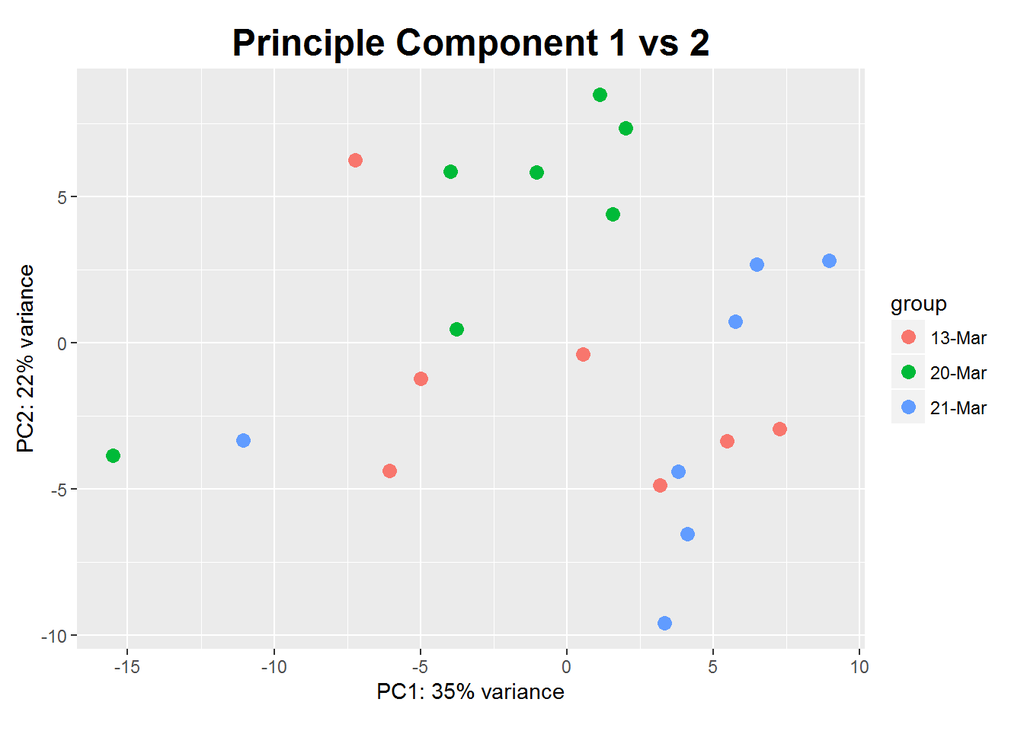

**21-Mar vs other 2:**  
DESEQ analysis using batch at factor, by creating a factor that distinguishes “21-Mar” batch from the other two

```r
isMar21<-relevel(as.factor(ifelse(samp3$date=="21-Mar","21-Mar","other")),ref="other")

sampb1<-cbind(samp3,isMar21)
resb1<-results(DESeq(DESeqDataSetFromMatrix(countData = gtab3,colData = sampb1,design= ~strain+isMar21)))
B1<-top_genes(resb1,num=length(which(resb1$padj<0.05)))
```

```
## [1] "226 genes found with padj<0.05"
```

```r
ktab(B1[1:5,])
```

|  | Locus.tag | Protein.name | FuncName1 | FuncName2 | FuncName3 | FuncName4 | ME_name | log10.padj | log2FoldChange | baseMean |
| --- | --- | --- | --- | --- | --- | --- | --- | --- | --- | --- |
| pred_RNA_26522bp_r | NA | downstrm_tadA: opp_strnd | pred_RNA | pred_RNA | pred_RNA | pred_RNA | NA | -12.0 | -1.20 | 636 |
| pred_RNA_3879807bp | NA | within_rocA: opp_strand | pred_RNA | pred_RNA | pred_RNA | pred_RNA | NA | -9.9 | -1.00 | 61 |
| pred_RNA_650171bp_r | NA | within_groES: opp_strand | pred_RNA | pred_RNA | pred_RNA | pred_RNA | NA | -8.9 | -0.81 | 90 |
| pred_RNA_2331535bp | NA | upstrm_ypsB: opp_strand difexp BSU22180 | pred_RNA | pred_RNA | pred_RNA | pred_RNA | NA | -7.7 | -1.00 | 97 |
| rimI | BSU05930 | ribosomal-protein-alanine acetyltransferase | Information processing | protein synthesis, modification and degradation | translation | translation/ other/ based on similarity | nonphage | -7.7 | -0.80 | 404 |

- can see that the most drastically changed transcripts were mostly predicted RNAs

**Table of DEGs (differentially-expressed genes) based on their level-1 Functions:**

DEGs: Number of differentially expressed genes all_in_cat: total number of genes in genome in this catagory perc: the percentage of genes in this category that were dif. expressed Up/Dwn: Number of DEGs in category that had increased or decreased expression relative to the reference level

```r
factor_tab(B1,"FuncName1")
```

```
##                               FuncName1 DEGs all_in_cat    perc Up Dwn
## 1                            Metabolism   28        831 0.03370 21   7
## 2                    Cellular processes   21        640 0.03280 16   5
## 3                       Groups of genes   26       1011 0.02570 16  10
## 4                Information processing   14        748 0.01870  6   8
## 5                            Lifestyles   11        694 0.01590  7   4
## 6 Prophages and mobile genetic elements    2        251 0.00797  2   0
## 7                              pred_RNA  119         NA      NA  3 116
## 8                         no assignment    5         NA      NA NA  NA
```

- over half of the Differentially Expressed Genes (DEGs) are pred_RNAs, and almost all of them are downreguated
- metabolism and cell process DEGs are also generally more upregulated

Functional group, level 2:

```
##                                            FuncName2 DEGs all_in_cat    perc Up Dwn
## 1                      RNA synthesis and degradation    3         53 0.05660  2   1
## 2                    amino acid/ nitrogen metabolism   10        179 0.05590  7   3
## 3               electron transport and ATP synthesis    5         93 0.05380  4   1
## 4                                   lipid metabolism    3         69 0.04350  0   3
## 5                    cell envelope and cell division    8        186 0.04300  5   3
## 6                                 coping with stress    9        226 0.03980  7   2
## 7                      additional metabolic pathways    7        202 0.03470  7   0
## 8                                       transporters   13        430 0.03020 11   2
## 9                       proteins of unknown function   20        670 0.02990 13   7
## 10            poorly characterized/ putative enzymes    4        135 0.02960  2   2
## 11   protein synthesis, modification and degradation    6        320 0.01880  1   5
## 12                                          genetics    3        171 0.01750  2   1
## 13                                 carbon metabolism    3        199 0.01510  3   0
## 14 exponential and early post-exponential lifestyles    1         81 0.01230  0   1
## 15                                 membrane proteins    2        182 0.01100  1   1
## 16                     regulation of gene expression    2        204 0.00980  1   1
## 17                                         prophages    2        243 0.00823  2   0
## 18                                       sporulation    1        378 0.00265  0   1
## 19                                          pred_RNA  119         NA      NA  3 116
## 20                                     no assignment    5         NA      NA NA  NA
```

**20-Mar analysis:**

```
## [1] "669 genes found with padj<0.05"
```

|  | Locus.tag | Protein.name | FuncName1 | FuncName2 | FuncName3 | FuncName4 | ME_name | log10.padj | log2FoldChange | baseMean |
| --- | --- | --- | --- | --- | --- | --- | --- | --- | --- | --- |
| pred_RNA_647848bp_r | NA | within_tatAY: opp_strand difexp BSU05980 | pred_RNA | pred_RNA | pred_RNA | pred_RNA | NA | -7.0 | 1.40 | 111 |
| yloN | BSU15750 | dual-specificity RNA methyltransferase RlmN | Information processing | protein synthesis, modification and degradation | translation | rRNA modification and maturation/ based on similarity | nonphage | -6.6 | -0.26 | 1314 |
| yneK | BSU17960 | hypothetical protein BSU17960 | Groups of genes | membrane proteins | NA | NA | nonphage | -6.6 | 0.42 | 794 |
| pred_RNA_2797114bp | NA | within_yrzB: opp_strand difexp BSU27380 | pred_RNA | pred_RNA | pred_RNA | pred_RNA | NA | -6.3 | 1.20 | 86 |
| trnI-Thr | NA | NA | NA | NA | NA | NA | NA | -6.2 | 0.73 | 48 |
| yhjA | BSU10440 | hypothetical protein BSU10440 | Groups of genes | proteins of unknown function | NA | NA | nonphage | -6.2 | 0.50 | 724 |
| yqkE | BSU23630 | hypothetical protein BSU23630 | Groups of genes | proteins of unknown function | NA | NA | nonphage | -6.2 | 0.75 | 151 |
| pred_RNA_5485bp_r | NA | within_gyrB: opp_strand | pred_RNA | pred_RNA | pred_RNA | pred_RNA | NA | -5.9 | 1.20 | 32 |
| trnD-Cys | NA | NA | NA | NA | NA | NA | NA | -5.2 | 0.84 | 135 |

```
##                               FuncName1 DEGs all_in_cat   perc Up Dwn
## 1                            Metabolism  165        831 0.1990 24 141
## 2                       Groups of genes  142       1011 0.1400 69  73
## 3                    Cellular processes   83        640 0.1300 18  65
## 4                Information processing   72        748 0.0963 32  40
## 5                            Lifestyles   51        694 0.0735 32  19
## 6 Prophages and mobile genetic elements   10        251 0.0398  5   5
## 7                              pred_RNA  106         NA     NA 93  13
## 8                         no assignment   40         NA     NA NA  NA
```

- 20% of metabolic genes have differential expression, most of them down

```
##                                            FuncName2 DEGs all_in_cat   perc Up Dwn
## 1                               GTP-binding proteins    1          3 0.3330  1   0
## 2                    amino acid/ nitrogen metabolism   59        179 0.3300  2  57
## 3             poorly characterized/ putative enzymes   30        135 0.2220  9  21
## 4                            mobile genetic elements    1          5 0.2000  0   1
## 5                      additional metabolic pathways   40        202 0.1980  4  36
## 6                      RNA synthesis and degradation   10         53 0.1890  4   6
## 7                              nucleotide metabolism   16         89 0.1800 12   4
## 8                                    essential genes    1          6 0.1670  0   1
## 9               electron transport and ATP synthesis   14         93 0.1510  2  12
## 10                                coping with stress   34        226 0.1500 23  11
## 11                                      transporters   60        430 0.1400 12  48
## 12                                 carbon metabolism   27        199 0.1360  2  25
## 13                      proteins of unknown function   89        670 0.1330 43  46
## 14                                  lipid metabolism    9         69 0.1300  2   7
## 15                                 membrane proteins   21        182 0.1150 16   5
## 16                   cell envelope and cell division   21        186 0.1130  5  16
## 17                         lifestyles/ miscellaneous    1          9 0.1110  1   0
## 18   protein synthesis, modification and degradation   35        320 0.1090 20  15
## 19                                       homeostasis    2         24 0.0833  1   1
## 20                     regulation of gene expression   15        204 0.0735  3  12
## 21                                          genetics   12        171 0.0702  5   7
## 22 exponential and early post-exponential lifestyles    5         81 0.0617  2   3
## 23                                         prophages    9        243 0.0370  5   4
## 24                                       sporulation   11        378 0.0291  6   5
## 25                                          pred_RNA  106         NA     NA 93  13
## 26                                     no assignment   40         NA     NA NA  NA
```

- echos above conclusion - many metabolic processes have reduced expression
- this is also suggested by the max GRs achieved by the cultures on that day - which were somewhat slower than on the other two days ..*this also contributed to the cultures being harvested across a slightly wider OD range on that date

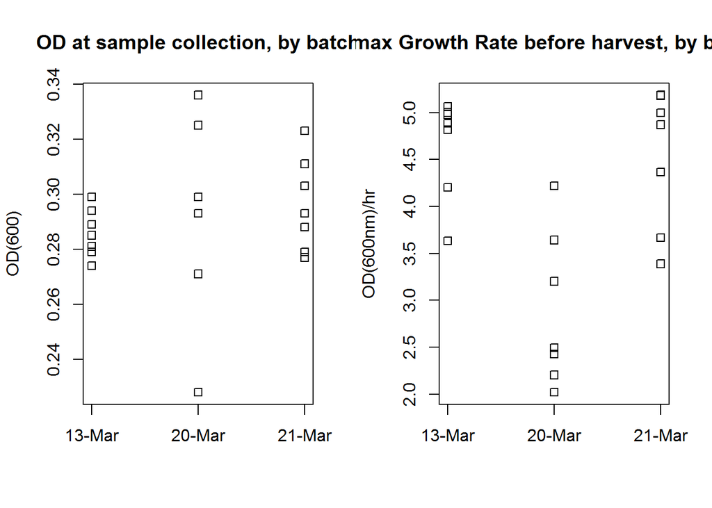

- Unfortunately, most of the expression variance in this dataset is due to slightly different growth rates on different days, and differences in the OD when the cultures were harvested.

**Poisson Clustering:**

Samp3 file includes a factor named “cluster” based on the groups defined by Poisson clustering this group (see `Rock2-DeSeq-walkthrough_in_markdown`), which are marked and labeled in the following image

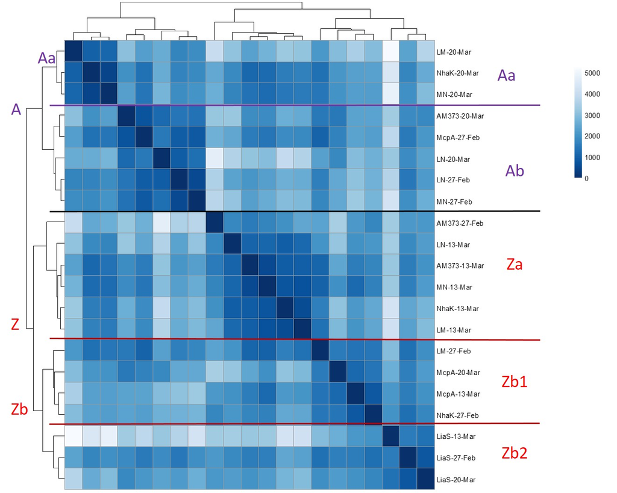

There is slight correlation between the Poisson cluster and maxGR reached by each sample, in which the “A” clusters generally acheived faster growth rates. However, there seems to be little relationship to OD at which the cells were harvested.

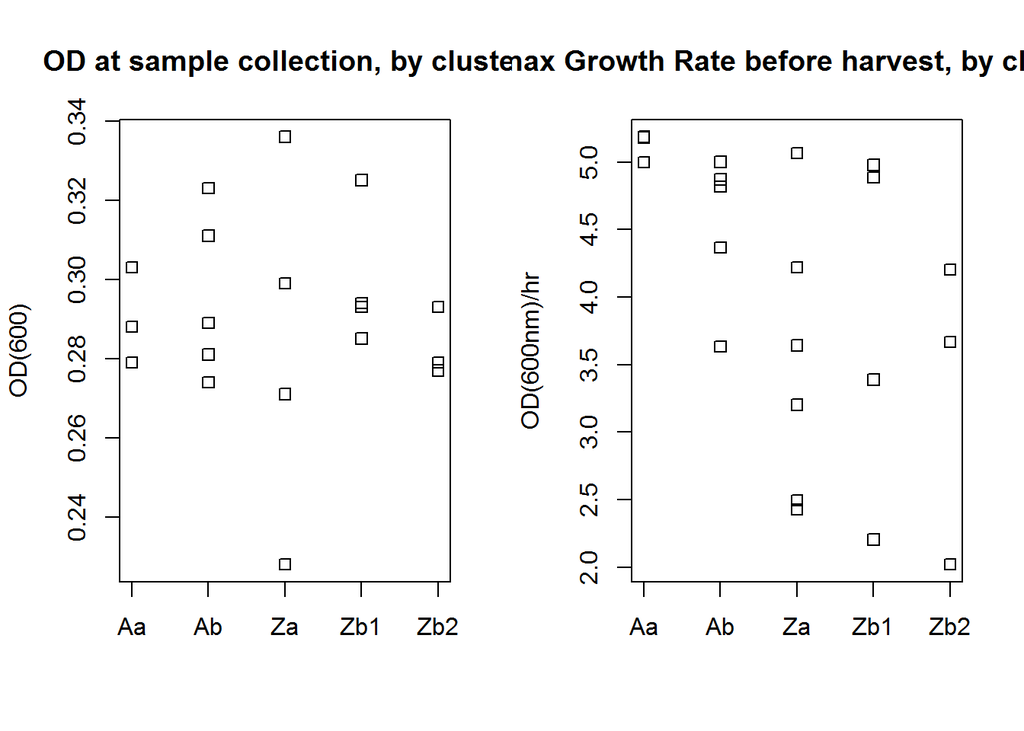

(although there is a lot of overlap in the growth rate ranges spanned by each group)

DEG analysis of cluster A v Z:

```
## [1] "1104 genes found with padj<0.05"
```

|  | Locus.tag | Protein.name | FuncName1 | FuncName2 | FuncName3 | FuncName4 | ME_name | log10.padj | log2FoldChange | baseMean |
| --- | --- | --- | --- | --- | --- | --- | --- | --- | --- | --- |
| yxbC | BSU39880 | hypothetical protein BSU39880 | Groups of genes | proteins of unknown function | NA | NA | nonphage | -22 | 0.98 | 342 |
| asnH | BSU39920 | asparagine synthetase 2 | Metabolism | amino acid/ nitrogen metabolism | biosynthesis/ acquisition of amino acids | biosynthesis/ acquisition of aspartate/ asparagine | nonphage | -17 | 0.98 | 354 |
| ureA | BSU36660 | urease subunit gamma | Metabolism | amino acid/ nitrogen metabolism | utilization of nitrogen sources other than amino acids | utilization of urea | nonphage | -14 | 1.10 | 157 |
| yxbB | BSU39890 | hypothetical protein BSU39890 | Groups of genes | proteins of unknown function | NA | NA | nonphage | -13 | 1.10 | 232 |
| aslA | BSU39900 | hypothetical protein BSU39900 | Groups of genes | poorly characterized/ putative enzymes | NA | NA | nonphage | -13 | 1.10 | 47 |
| ureC | BSU36640 | urease subunit alpha | Metabolism | amino acid/ nitrogen metabolism | utilization of nitrogen sources other than amino acids | utilization of urea | nonphage | -13 | 1.00 | 604 |
| narK | BSU37320 | nitrite extrusion protein | Cellular processes | transporters | transporters/ other | NA | nonphage | -12 | 1.30 | 135 |
| ilvA | BSU21770 | threonine dehydratase | Metabolism | amino acid/ nitrogen metabolism | biosynthesis/ acquisition of amino acids | biosynthesis/ acquisition of branched-chain amino acids | nonphage | -12 | 0.41 | 3030 |
| leuB | BSU28270 | 3-isopropylmalate dehydrogenase | Metabolism | amino acid/ nitrogen metabolism | biosynthesis/ acquisition of amino acids | biosynthesis/ acquisition of branched-chain amino acids | nonphage | -11 | 0.72 | 2776 |

```
##                               FuncName1 DEGs all_in_cat  perc  Up Dwn
## 1                            Metabolism  242        831 0.291 190  52
## 2                    Cellular processes  146        640 0.228  91  55
## 3                Information processing  145        748 0.194  57  88
## 4                       Groups of genes  180       1011 0.178 105  75
## 5 Prophages and mobile genetic elements   43        251 0.171  13  30
## 6                            Lifestyles   70        694 0.101  55  15
## 7                              pred_RNA  225         NA    NA  14 211
## 8                         no assignment   53         NA    NA  NA  NA
```

```
##                              FuncName2 DEGs all_in_cat  perc Up Dwn
## 1      amino acid/ nitrogen metabolism   77        179 0.430 70   7
## 2                nucleotide metabolism   26         89 0.292  4  22
## 3        additional metabolic pathways   58        202 0.287 52   6
## 4                    carbon metabolism   51        199 0.256 41  10
## 5 electron transport and ATP synthesis   19         93 0.204 17   2
## 6                     lipid metabolism   11         69 0.159  6   5
```

```
##                         FuncName2 DEGs all_in_cat  perc Up Dwn
## 1 cell envelope and cell division   49        186 0.263 27  22
## 2                    transporters   94        430 0.219 62  32
## 3                     homeostasis    3         24 0.125  2   1
```

```
##                                         FuncName2 DEGs all_in_cat  perc Up Dwn
## 1                   RNA synthesis and degradation   13         53 0.245  6   7
## 2 protein synthesis, modification and degradation   71        320 0.222 24  47
## 3                                        genetics   31        171 0.181 11  20
## 4                   regulation of gene expression   30        204 0.147 16  14
```

```
##                 FuncName3 DEGs all_in_cat   perc Up Dwn
## 1 motility and chemotaxis   16         57 0.2810 14   2
## 2       biofilm formation    1         24 0.0417  0   1
```

- Functional analysis basically re-interates that the group “A” clusters have increased metabolism, related to increased amino acid/nitrogen and carbon metabolism, electron transport, and expression of stress response genes. Also have increased expression of motility and chemotaxis genes.

### 4. Examine effect of antibiotic markers

#### 4.1 Kanamycin

Examine whether there is evidence that the kanamycin resistance marker correlates to gene expression changes. In samp3, there is a column “kan”, that indicates whether a strain harbors the kan resistance gene (yes/no) that is used to perform this analysis.

```r
options(width=150)
resKan<-results(DESeq(DESeqDataSetFromMatrix(countData = gtab3,colData = samp3,design= ~date+kan)))
resKansig<-resKan[order(resKan$padj),]
kable(resKansig[1:4,],format="markdown",digits = 4)
```

|  | baseMean | log2FoldChange | lfcSE | stat | pvalue | padj |
| --- | --- | --- | --- | --- | --- | --- |
| nhaK | 131.0603 | -2.8741 | 0.1059 | -27.1341 | 0.0000 | 0.0000 |
| dnaA | 4464.5955 | -0.1652 | 0.0784 | -2.1070 | 0.0351 | 0.6307 |
| pred_RNA_8982bp_r | 50.6357 | -0.3220 | 0.1563 | -2.0604 | 0.0394 | 0.6307 |
| rnmV | 454.7341 | -0.2572 | 0.1044 | -2.4638 | 0.0137 | 0.6307 |

- See that only NhaK expression is significantly associated, which is expected (All NhaK KO’s are Kan-resistant)
- Only one assayed $\Delta$ mcpA strain has a kan marker (MN)

#### 4.2 Zeocin

```r
resZeo<-results(DESeq(DESeqDataSetFromMatrix(countData = gtab3,colData = samp3,design= ~date+zeo)))
resZeosig<-resZeo[order(resZeo$padj),]
kable(resZeosig[1:4,],format="markdown",digits=4)
```

|  | baseMean | log2FoldChange | lfcSE | stat | pvalue | padj |
| --- | --- | --- | --- | --- | --- | --- |
| pred_RNA_3206218bp | 56.9204 | 2.2856 | 0.1855 | 12.3214 | 0e+00 | 0.0000 |
| pred_RNA_3631194bp | 217.5539 | -0.7103 | 0.1758 | -4.0412 | 1e-04 | 0.0817 |
| pred_RNA_3915345bp | 125.5335 | -0.6714 | 0.1635 | -4.1072 | 0e+00 | 0.0817 |
| pred_RNA_158219bp_r | 180.9505 | -0.6576 | 0.1730 | -3.8018 | 1e-04 | 0.0844 |

- See a bunch of predicted RNAs occupy top ranked most differentially expressed
- only top one (pred_RNA_3206218bp) is stat sig (10<sup>-31</sup>); that locus is within mcpA gene
- next one in list is the opposite strand of the yvyD gene(sigma modulator), and then opposite strand of 5’end of qoxB (quinone)

**Plots of RNA 3206218 and mcpA transcription levels, by strain and by presence of zeocin cassette:**

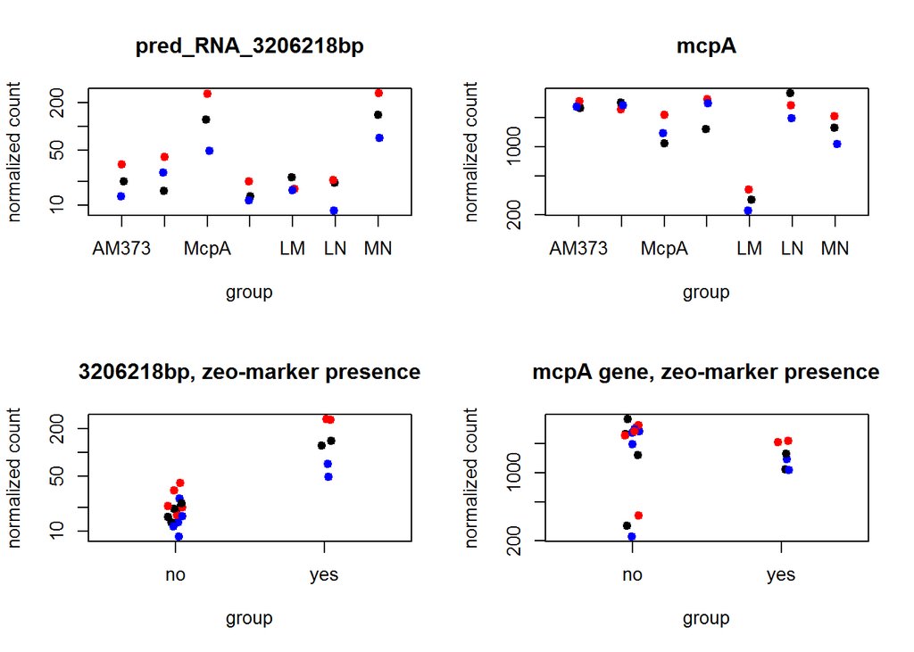

Summary conclusions, zeocin effects:  
* `pred_RNA_3206218bp` is only elevated in strains with zeocin cassette, ie, the McpA and MN strain  
* mcpA expression in strains McpA and MN look almost as high as in non-deleted strains, while it is much lower in LM  
* both effects may be from transcription of zeocin gene and its immediate upstream region, which was put on the opposite strand of mcpA; however, in LM the antiboitic cassette was completely removed by Cre recombinase, so the antibiotic is not driving transcription in that region

This CLC workbench image of its mapping of these reads shows that the bulk of the mcpA gene had very few reads (ie, was successfully deleted), but a glut of reads of the non-deleted 3’end of the gene (mcpA is encoded on bottom strand) that likely account for a relatively high total count of reads found for the gene in these strains.

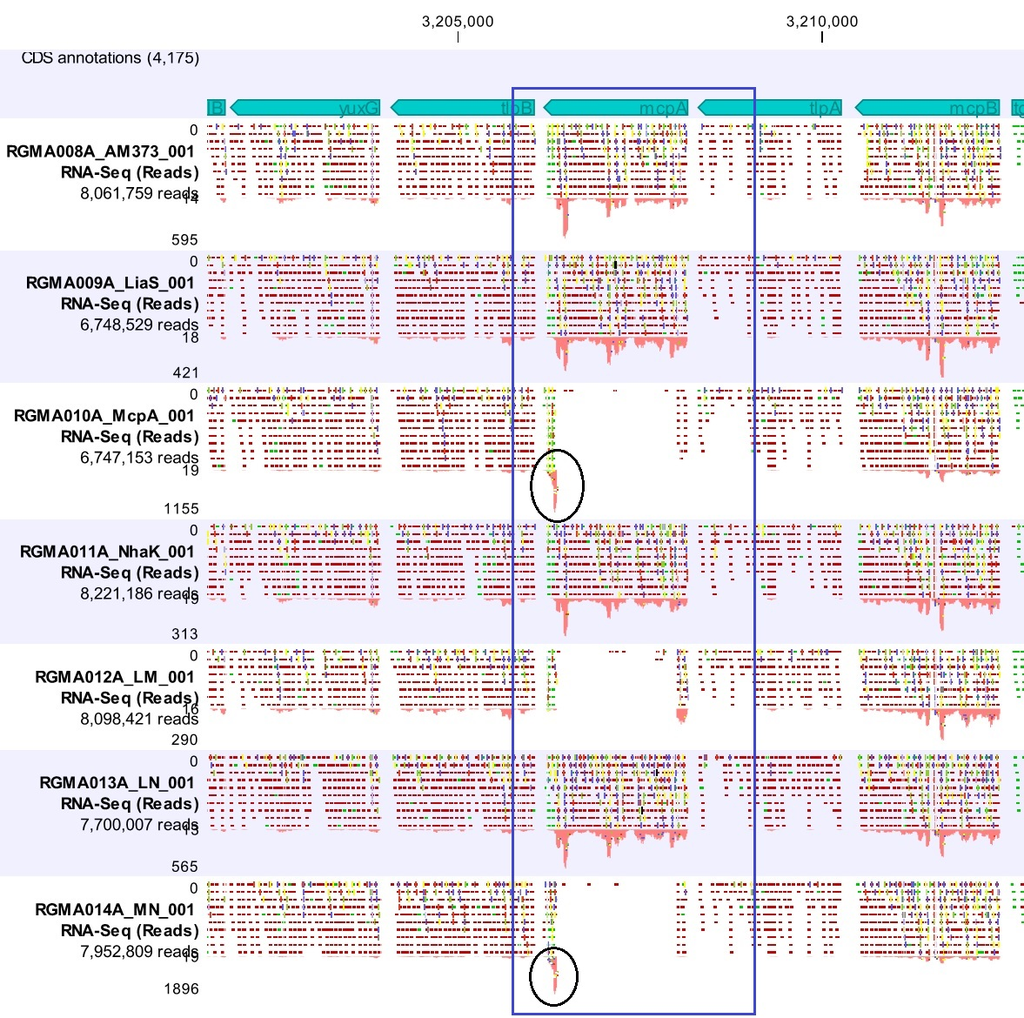

The top bar in the above image displays the genes in displayed section of the mapped genome, with the position of the mcpA gene indicated by the blue box. The mapped reads of each library (one per strain) are disiplayed bellow. The name of the library indicates the strain between the two undercores. Circles highlight the 3’ end of the mcpA gene in strains McpA and MN, where there are an accumulation of reads that account for the high total of reads recorded for the gene despite the gene being non-functional - as the transcripts are clearly missing most of the gene as designed.

### 5. Number of Differentially-expressed genes between each pair of strains

1. Generate table that creates all pair-wise combinations of the 7 strains
2. Generate contrasts from each pair of strians in combst
- name of each analysis is the concatenation of both strain names

```r
#The following function, "contrastx", generates a contrast given a vector with the names of both strains
   #This function also names the output based on the names of the strains

contrastx<-function(x){

  out<-results(ds,contrast=c("strain",x[1],x[2]))  #calculate DEGs between strain1 and strain2
  out<-out[order(out$padj),]
  assign(paste0(x[1],"_",x[2]),out,envir = .GlobalEnv)  #each analysis is named "strain1_strain2"
  }

res_cont<-apply(combst,MARGIN = 2,FUN=contrastx)
```

3. Table of number of differentially-expressed genes between each pair:

```
##    number of DEGs: p>0.01 p>0.001
## 1       AM373_LiaS     59      50
## 2       AM373_McpA      5       1
## 3       AM373_NhaK      5       4
## 4         AM373_LM     23      12
## 5         AM373_LN     23      16
## 6         AM373_MN      3       2
## 7        LiaS_McpA    118      72
## 8        LiaS_NhaK     71      58
## 9          LiaS_LM    125      73
## 10         LiaS_LN     51      48
## 11         LiaS_MN    136      74
## 12       McpA_NhaK      2       2
## 13         McpA_LM     13       8
## 14         McpA_LN     19      15
## 15         McpA_MN      1       1
## 16         NhaK_LM      5       5
## 17         NhaK_LN     14      13
## 18         NhaK_MN      1       1
## 19           LM_LN     13      13
## 20           LM_MN      6       6
## 21           LN_MN     15      15
```

**Discussion of Table:**

- $\Delta$ liaS associated with the most gene expression changes
- Relative to reference strain AM373, the $\Delta$ liaS single-KO strain has the most genes differentially expressed, followed by the LiaS-combination mutants
- McpA, MN, and NhaK have very few expression changes
- LiaS strain likely has largest number of expression changes due to failure to purge pTSC-Tet plasmid
- LiaS also has a large number of DEGs when contrasted with strains harboring McpA mutation; this is not really seen in LN vs McpA, so may be due to pTSC-Tet

### 6. Analysis of Differential Expression between groups of strains

#### 6.1 $\Delta$ liaS strain analysis

#### 6.1.1 LiaS vs AM373 reference strain

1. Generate table of Differentially Expressed Genes (DEGs)
- table organized to display genes in descending order of strength of differential expression
- only the top 10 displayed

```
## [1] "76 genes found with padj<0.05"
```

|  | Locus.tag | Protein.name | FuncName1 | FuncName2 | FuncName3 | FuncName4 | ME_name | log10.padj | log2FoldChange | baseMean |
| --- | --- | --- | --- | --- | --- | --- | --- | --- | --- | --- |
| yddK | BSU05000 | hypothetical protein BSU05000 | Groups of genes | proteins of unknown function | ICEBs1 | NA | ICEBs1 | -Inf | 6.7 | 1746 |
| immR | BSU04820 | XRE family transcriptional regulator | Information processing | regulation of gene expression | transcription factors and their control | transcription factors/ other | ICEBs1 | -110 | 4.8 | 490 |
| rapI | BSU05010 | response regulator aspartate phosphatase I | Information processing | protein synthesis, modification and degradation | protein modification | protein phosphatases | ICEBs1 | -110 | 4.7 | 359 |
| yddM | BSU05030 | helicase | Groups of genes | membrane proteins | ICEBs1 | NA | ICEBs1 | -91 | 4.4 | 272 |
| ydcL | BSU04800 | ICEBs1 integrase | Prophages and mobile genetic elements | mobile genetic elements | ICEBs1 | NA | ICEBs1 | -81 | 4.4 | 737 |
| liaS | BSU33090 | sensor histidine kinase | Information processing | protein synthesis, modification and degradation | protein modification | protein kinases | nonphage | -76 | 3.2 | 160 |
| immA | BSU04810 | metallopeptidase ImmA | Information processing | protein synthesis, modification and degradation | proteolysis | NA | ICEBs1 | -65 | 4.0 | 257 |
| yddJ | BSU04990 | hypothetical protein BSU04990 | Groups of genes | proteins of unknown function | ICEBs1 | NA | ICEBs1 | -43 | 3.3 | 146 |
| phrI | BSU05020 | secreted regulator of the activity of phosphatase RapI | Information processing | protein synthesis, modification and degradation | protein modification | protein phosphatases | ICEBs1 | -33 | 2.9 | 46 |
| liaH | BSU33120 | lia operon expression modulator LiaH | Lifestyles | coping with stress | resistance against oxidative and electrophile stress | NA | nonphage | -23 | 2.4 | 373 |

Note: `pred_RNA_1325022bp`: intergenic region between xpf and xtmA (both PBSX genes) * already annotated on subtiwiki as `new_1325005_1325095` / S456: 5’ UTR of xtmA

2. Functional classification of differentially-expressed genes:

2a. Identify any GoH core genes with increased expression:

```r
ktab(AL[which(AL$GoH.Core=="GoH_core"),])
```

|  | Locus.tag | Protein.name | FuncName1 | FuncName2 | FuncName3 | FuncName4 | ME_name | log10.padj | log2FoldChange | baseMean |
| --- | --- | --- | --- | --- | --- | --- | --- | --- | --- | --- |
| xhlA | BSU12790 | phage-like element PBSX protein XhlA | Prophages and mobile genetic elements | prophages | PBSX prophage | NA | PBSX prophage | -2.7 | -1.1 | 308 |

- 1 GoH core gene: [xhlA](http://subtiwiki.uni-goettingen.de/bank/index.php?gene=xhlA&action=Go), a PBSX prophage gene; -1.06 fold change indicates higher expression in $\Delta$ liaS strain

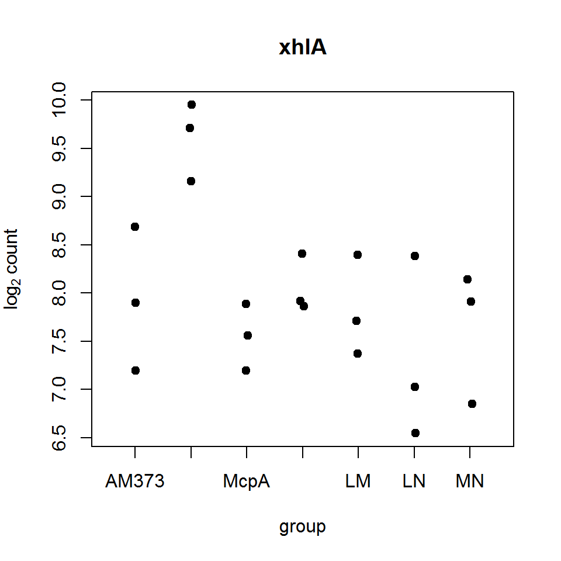

**2b. Tables of Differentially-Expressed Genes by Functional Category:**

Tables show how many genes are in the DEG list for that contrast, how many genes total are in that catagory, and what percent(perc) of all genes in that catagory are DEGs

```r
factor_tab(AL,"FuncName1")  # Top Level Functional Category
```

```
##                               FuncName1 DEGs all_in_cat    perc Up Dwn
## 1 Prophages and mobile genetic elements   35        251 0.13900  4  31
## 2                Information processing   13        748 0.01740  7   6
## 3                       Groups of genes   14       1011 0.01380 11   3
## 4                    Cellular processes    6        640 0.00938  0   6
## 5                            Lifestyles    3        694 0.00432  3   0
## 6                            Metabolism    3        831 0.00361  0   3
## 7                              pred_RNA    2         NA      NA  0   2
```

```r
factor_tab(AL,"FuncName3")  # A mid-level Functional Category
```

```
##                                               FuncName3 DEGs all_in_cat    perc Up Dwn
## 1                                         PBSX prophage   30         32 0.93800  0  30
## 2                                                ICEBs1    9         20 0.45000  9   0
## 3                               lipid metabolism/ other    1          5 0.20000  0   1
## 4                 cell wall/ other/ based on similarity    1          7 0.14300  0   1
## 5        DNA repair/ recombination/ based on similarity    2         18 0.11100  0   2
## 6                                       DNA replication    2         24 0.08330  0   2
## 7                       cell wall degradation/ turnover    3         37 0.08110  0   3
## 8  resistance against oxidative and electrophile stress    2         25 0.08000  2   0
## 9                                          phosphorelay    1         16 0.06250  1   0
## 10                                 protein modification    3         65 0.04620  3   0
## 11                                utilization of lipids    1         23 0.04350  0   1
## 12                                        cell division    1         24 0.04170  0   1
## 13                                          proteolysis    1         27 0.03700  1   0
## 14                                        transcription    1         30 0.03330  0   1
## 15                                          respiration    1         33 0.03030  0   1
## 16                            DNA repair/ recombination    1         56 0.01790  0   1
## 17              transcription factors and their control    2        158 0.01270  2   0
## 18                                  cell wall synthesis    1         80 0.01250  0   1
## 19                                     SP-beta prophage    2        160 0.01250  1   1
## 20                                          translation    1        178 0.00562  1   0
## 21                                             pred_RNA    2         NA      NA  0   2
## 22                                        no assignment    8         NA      NA NA  NA
```

```r
factor_tab(AL,"ME_name")    # Phage/Mobile Element Classifier
```

```
##            ME_name DEGs all_in_cat    perc Up Dwn
## 1    PBSX prophage   36         42 0.85700  0  36
## 2           ICEBs1   13         27 0.48100 13   0
## 3     Skin element    1         61 0.01640  1   0
## 4 SP-beta prophage    2        189 0.01060  1   1
## 5         nonphage   22       3829 0.00575 10  12
## 8    no assignment    2         NA      NA NA  NA
```

Can see that ~ 50 of 76 DEGs belong to PBSX or the ICEBs1 Mobile element

Plot of expression shifts of ME/Phage genes:

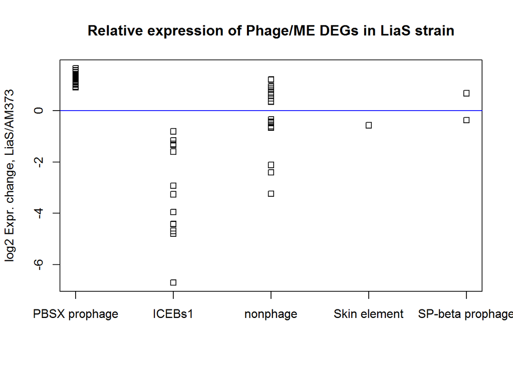

- PBSX genes have significantly higher expression in $\Delta$ liaS strain
- Meanwhile, ICEBs1 gene expression is lower

Functional catagories of non-phage DEGs:

```
##                                          FuncName2 DEGs all_in_cat    perc Up Dwn
## 1                                 lipid metabolism    2         69 0.02900  0   2
## 2                                         genetics    3        171 0.01750  0   3
## 3                  cell envelope and cell division    3        186 0.01610  0   3
## 4             electron transport and ATP synthesis    1         93 0.01080  0   1
## 5                     proteins of unknown function    6        670 0.00896  3   3
## 6                               coping with stress    2        226 0.00885  2   0
## 7           poorly characterized/ putative enzymes    1        135 0.00741  1   0
## 8  protein synthesis, modification and degradation    2        320 0.00625  2   0
## 9                                membrane proteins    1        182 0.00549  1   0
## 10                                     sporulation    1        378 0.00265  1   0
```

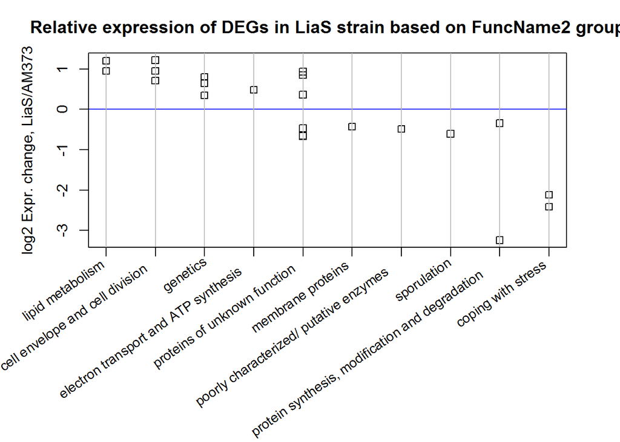

- Up-regulated groups: Several groups associated with faster growth (lipid metabolism, division, ATP synthesis, “genetics”)
- Down-regulated groups: Sporulation (matches measured phenotype!), stress response, protein degradation
- Most genes are still in the “unknown function” group

#### 5.1.2 LiaS single-KO strain vs all other strains

**Genes uniquely differentially expressed in strain $\Delta$ liaS**

```
## [1] "253 genes found with padj<0.05"
```

|  | Locus.tag | Protein.name | FuncName1 | FuncName2 | FuncName3 | FuncName4 | ME_name | log10.padj | log2FoldChange | baseMean |
| --- | --- | --- | --- | --- | --- | --- | --- | --- | --- | --- |
| fadG | BSU14071 | hypothetical protein BSU14071 | Metabolism | lipid metabolism | utilization of lipids | utilization of fatty acids | nonphage | -50 | 1.3 | 884 |
| pred_RNA_1325022bp | NA | downstrm_xpf: same_strnd difexp BSU12560 | pred_RNA | pred_RNA | pred_RNA | pred_RNA | NA | -23 | 2.1 | 56 |
| xkdE | BSU12590 | phage-like element PBSX protein XkdE | Prophages and mobile genetic elements | prophages | PBSX prophage | NA | PBSX prophage | -19 | 1.9 | 292 |
| xkdC | BSU12530 | phage-like element PBSX protein XkdC | Prophages and mobile genetic elements | prophages | PBSX prophage | NA | PBSX prophage | -19 | 2.2 | 27 |
| xtmB | BSU12580 | PBSX phage terminase large subunit | Information processing | genetics | DNA replication | NA | PBSX prophage | -18 | 1.9 | 214 |
| xkdB | BSU12520 | phage-like element PBSX protein XkdB | Prophages and mobile genetic elements | prophages | PBSX prophage | NA | PBSX prophage | -17 | 2.1 | 15 |
| xkdP | BSU12690 | phage-like element PBSX protein XkdP | Prophages and mobile genetic elements | prophages | PBSX prophage | NA | PBSX prophage | -16 | 1.8 | 221 |
| xpf | BSU12560 | positive control factor | Information processing | RNA synthesis and degradation | transcription | sigma factors | PBSX prophage | -16 | 2.1 | 21 |
| xkdD | BSU12540 | phage-like element PBSX protein XkdD | Prophages and mobile genetic elements | prophages | PBSX prophage | NA | PBSX prophage | -16 | 2.3 | 12 |

- See that a lipid metabolism gene and a bunch of PBSX phage-associated genes are specifically more highly expressed in the LiaS strain - even above the expression of those genes in LN or LM
- (`pred_RNA_1325022bp` - located between two PBSX prophage genes, all 3 coded on same strand)
- the other known factor that is unique to the L strain is that it is the only strain profiled while harboring pTSC-Tet, suggesting that this plasmid may somehow activate expression of PBSX
- One **GoH-core gene** is a DEG: xhlA, the PBSX prophage element found previously between LiaS v AM373

**Prophage-associated DEGs (L vs all):**

```
##            ME_name DEGs all_in_cat   perc Up Dwn
## 1    PBSX prophage   36         42 0.8570 36   0
## 2           ICEBs1    6         27 0.2220  0   6
## 3       Prophage 3    1          9 0.1110  0   1
## 4     Skin element    3         61 0.0492  0   3
## 5         nonphage  111       3829 0.0290 38  73
## 6 SP-beta prophage    5        189 0.0265  3   2
## 8    no assignment   91         NA     NA NA  NA
```

When comparing the liaS strain to all others, not as many phage genes are found - suggesting other strains have similarly altered expression levels of some phage genes (note: ‘’ is assigned to pred_RNA genes)

However, **PBSX expression appears to be unique to the liaS single-gene KO strain**; liaS has 36 PBSX DEGs in both contrasts; either the liaS gene or the presence of pTSC-Tet may be responsible.

However, now have 111 nonphage associated DEGs (vs 22 when liaS strain was contrasted with AM373 alone)

**Nonphage DEGs: First level of naming (only 5 Functional catagories):**

```
##                FuncName1 DEGs all_in_cat   perc Up Dwn
## 1             Metabolism   44        831 0.0529  6  38
## 2 Information processing   21        748 0.0281 12   9
## 3        Groups of genes   23       1011 0.0227 10  13
## 4             Lifestyles   12        694 0.0173  4   8
## 5     Cellular processes   11        640 0.0172  6   5
```

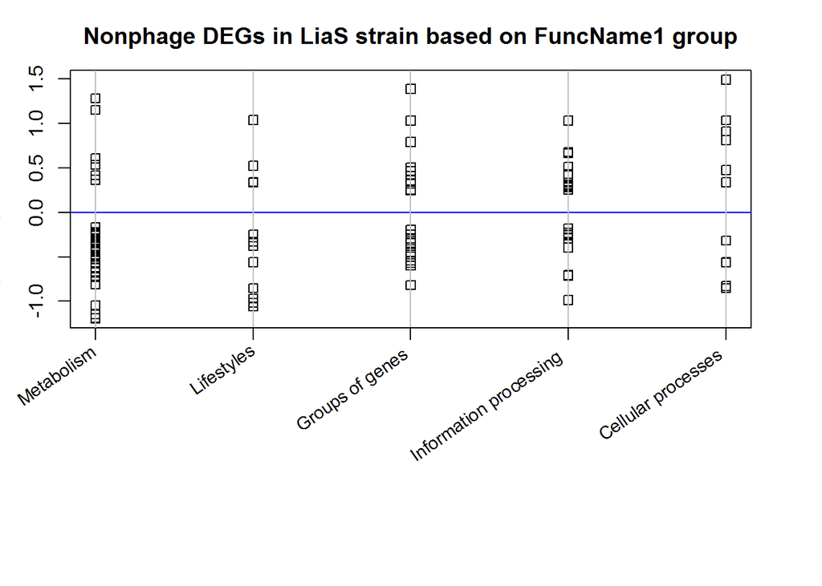

- none of the functional catagories are consistantly altered in a single direction; no meaningful information here

**Second Level Functional Names:**

```
##                                            FuncName2 DEGs all_in_cat    perc Up Dwn
## 1                                    essential genes    1          6 0.16700  0   1
## 2               electron transport and ATP synthesis   14         93 0.15100  1  13
## 3                                        homeostasis    3         24 0.12500  0   3
## 4                                   lipid metabolism    5         69 0.07250  2   3
## 5                                           genetics   12        171 0.07020  9   3
## 6                                  carbon metabolism   10        199 0.05030  0  10
## 7                    amino acid/ nitrogen metabolism    7        179 0.03910  2   5
## 8  exponential and early post-exponential lifestyles    3         81 0.03700  3   0
## 9                                 coping with stress    7        226 0.03100  0   7
## 10                     additional metabolic pathways    6        202 0.02970  1   5
## 11                   cell envelope and cell division    5        186 0.02690  5   0
## 12                             nucleotide metabolism    2         89 0.02250  0   2
## 13                      proteins of unknown function   15        670 0.02240  5  10
## 14            poorly characterized/ putative enzymes    3        135 0.02220  1   2
## 15                                 membrane proteins    4        182 0.02200  4   0
## 16                     RNA synthesis and degradation    1         53 0.01890  1   0
## 17   protein synthesis, modification and degradation    6        320 0.01880  1   5
## 18                     regulation of gene expression    2        204 0.00980  1   1
## 19                                      transporters    3        430 0.00698  1   2
## 20                                       sporulation    2        378 0.00529  1   1
```

Essential gene at the top of the list - yueK: nicotinate phosphoribosyltransferase

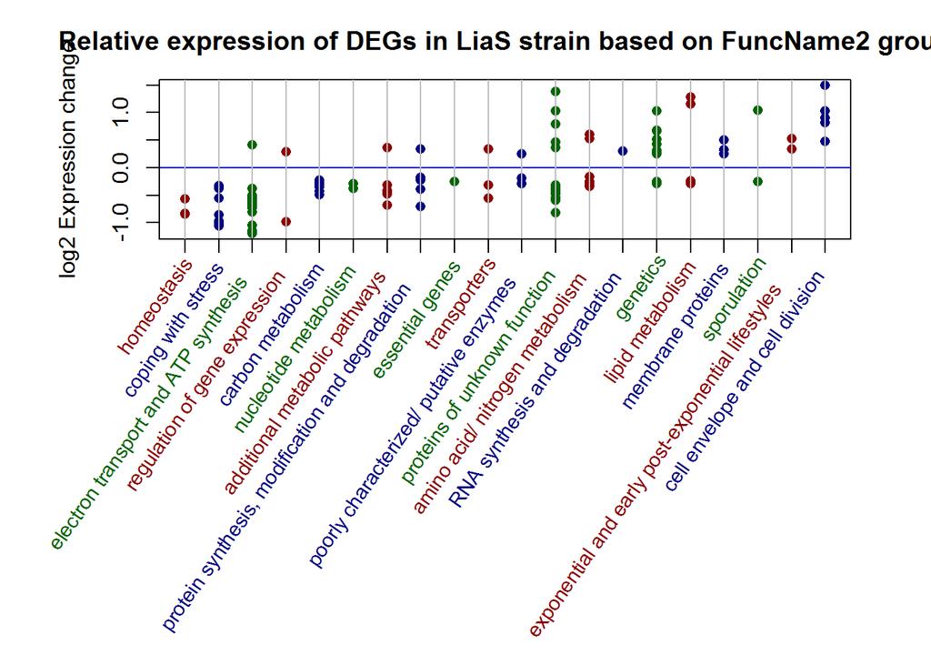

**down regulated:** now can see more clearly that significantly downregulated genes function within homeostasis, stress response, ATP synthesis, and carbon metabolism. Also 3 biosynthesis of fatty acids genes,

**up regulated**: “genetics”, cell division genes, some membrane proteins, proline biosynthesis. “Genetics” is mostly related to DNA replication and repair:

**DEGs within “Genetics” subcatagory:** Sorted by direction of change in expression

```
## DataFrame with 12 rows and 15 columns
##       baseMean log2FoldChange      lfcSE      stat       pvalue         padj                            Protein.name Locus.tag GoH.Core
##      <numeric>      <numeric>  <numeric> <numeric>    <numeric>    <numeric>                             <character>  <factor> <factor>
## yneB  166.2817      1.0313181  0.1586741  6.499600 8.053382e-11 9.774263e-09                          resolvase YneB  BSU17870       no
## dinB  125.9286      0.6788208  0.1811848  3.746566 1.792722e-04 9.186702e-03                            protein DinB  BSU05630       no
## yhaZ  207.7082      0.6657898  0.1422519  4.680356 2.863768e-06 2.751604e-04           hypothetical protein BSU09810  BSU09810       no
## lexA  442.5966      0.5132114  0.1357606  3.780268 1.566599e-04 8.500183e-03                          lexa repressor  BSU17850       no
## yqjH  223.9342      0.4314405  0.1090543  3.956199 7.615160e-05 5.017303e-03                     DNA polymerase IV 1  BSU23870       no
## ...        ...            ...        ...       ...          ...          ...                                     ...       ...      ...
## uvrC  409.2106      0.2811607 0.06491286  4.331355 1.481943e-05   0.00117840                 UvrABC system protein C  BSU28490       no
## yhaN  937.4997      0.2529145 0.08377144  3.019102 2.535252e-03   0.04811761           hypothetical protein BSU09920  BSU09920       no
## comQ 1573.7687     -0.2495579 0.08196836 -3.044564 2.330177e-03   0.04632661      competence regulatory protein ComQ  BSU31710       no
## comA 1533.4687     -0.2599411 0.08269014 -3.143556 1.669083e-03   0.03887784 transcriptional regulatory protein ComA  BSU31680       no
## yokA  939.6730     -0.2943709 0.09621348 -3.059560 2.216622e-03   0.04505422                          resolvase YokA  BSU21660       no
##                   FuncName1 FuncName2                                      FuncName3 FuncName4 Phage_ME  ME_name
##                    <factor>  <factor>                                       <factor>  <factor> <factor> <factor>
## yneB Information processing  genetics DNA repair/ recombination/ based on similarity        NA          nonphage
## dinB Information processing  genetics                      DNA repair/ recombination        NA          nonphage
## yhaZ Information processing  genetics DNA repair/ recombination/ based on similarity        NA          nonphage
## lexA Information processing  genetics                      DNA repair/ recombination        NA          nonphage
## yqjH Information processing  genetics                      DNA repair/ recombination        NA          nonphage
## ...                     ...       ...                                            ...       ...      ...      ...
## uvrC Information processing  genetics                      DNA repair/ recombination        NA          nonphage
## yhaN Information processing  genetics                      DNA repair/ recombination        NA          nonphage
## comQ Information processing  genetics                             genetic competence        NA          nonphage
## comA Information processing  genetics                             genetic competence        NA          nonphage
## yokA Information processing  genetics DNA repair/ recombination/ based on similarity        NA          nonphage
```

- almost all upregulated “genetics” DEGs involved in DNA repair/recombination
- 2/3 down-reguated DEGs involved in competence

**Third Level Functional Names:**

there are 39 level-3 functional catagories  
* too many to easily plot in one figure * “groups of genes” in FuncName1 set do not have any FuncName3 anotations, do not analyze

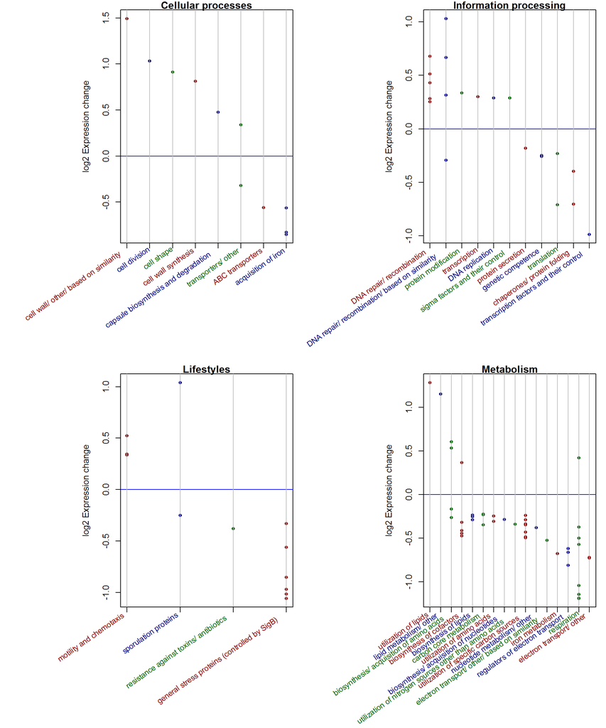

Upregulated functions: DNA repair/recombination, mobility and chemotaxis

Downregulated functions: Acquisition of iron, sigB stress proteins, biosynthesis of lipids and cofactors, utilization of specific carbon sources, respiration and electron transport

#### 5.1.3 All LiaS deletion strains vs all others

Analysis of all $\Delta$ liaS deletion strains (L, LN, LM) vs all others (A, M, N, MN)  
- use column `"L_gene"` in samp3, where ‘yes’ means *liaS* gene is intact

**Only get 4 DEGs:**

|  | Locus.tag | Protein.name | FuncName1 | FuncName2 | FuncName3 | FuncName4 | ME_name | log10.padj | log2FoldChange | baseMean |
| --- | --- | --- | --- | --- | --- | --- | --- | --- | --- | --- |
| liaS | BSU33090 | sensor histidine kinase | Information processing | protein synthesis, modification and degradation | protein modification | protein kinases | nonphage | -250.0 | 3.30 | 160 |
| liaH | BSU33120 | lia operon expression modulator LiaH | Lifestyles | coping with stress | resistance against oxidative and electrophile stress | NA | nonphage | -80.0 | 2.30 | 373 |
| liaI | BSU33130 | protein LiaI | Lifestyles | coping with stress | resistance against oxidative and electrophile stress | NA | nonphage | -54.0 | 2.10 | 139 |
| yorF | BSU20400 | hypothetical protein BSU20400 | Prophages and mobile genetic elements | prophages | SP-beta prophage | NA | SP-beta prophage | -1.3 | 0.49 | 67 |

- Three of the *lia* genes
- [yorF](http://subtiwiki.uni-goettingen.de/bank/index.php?gene=yorF&action=Go), an SP-beta1 prophage gene (function unknown)
  - yorF was not a DEG of LiaS-v-AM373 contrast

**Plots of the DEGs:**

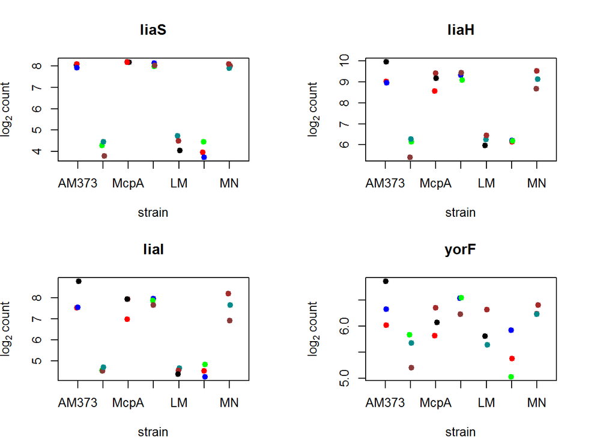

```
##      liaS liaH liaI yorF
## [1,]    1    1    1    1
## [2,]    2    2    2    2
## [3,]    3    3    3    3
## [4,]    4    4    4    4
## [5,]    5    5    5    5
## [6,]    6    6    6    6
## [7,]    7    7    7    7
```

- Expression of the 3 *liaS* genes is knocked down in all 3 $\Delta$ liaS strains, as expected given their known dependence on *liaS*
- *yorF* expression is only strongly reduced in strains L and LN, suggesting its expression change is due to something particular to those two strains ..* LN is directly derived from strain L, while LM was independently generated ..* L and LN have both since been found to have modification to ICEbs1 conjugative transposon (see later analysis), which may have also altered *yorF*, which is involved in regulation of a different prophage (SPbeta prophage)

**expression of all liaS genes between strains:**

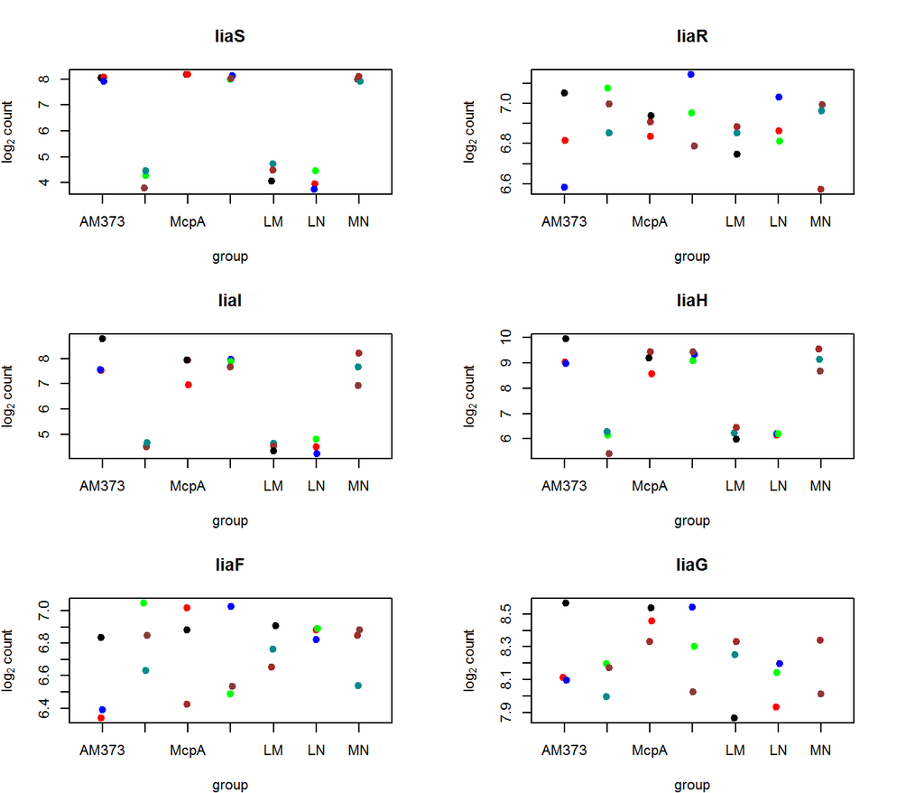

```
##      liaS liaR liaI liaH liaF liaG
## [1,]    1    1    1    1    1    1
## [2,]    2    2    2    2    2    2
## [3,]    3    3    3    3    3    3
## [4,]    4    4    4    4    4    4
## [5,]    5    5    5    5    5    5
## [6,]    6    6    6    6    6    6
## [7,]    7    7    7    7    7    7
```

- liaS expression down
- what is left is transcription from the remaining non-functional parts of the gene
- expression of lia F, G and R - which are in the same operon as liaS, are not changed in $\Delta$ liaS strains - confirming that seamless deletion succesfully preserved native expression of those genes
- expression of lia I, and H greatly reduced - proving that loss of liaS prevented liaR-transcription factor activation that induces liaIH expression

#### 5.1.4 Genes differentially-expressed in L and LN vs all others

```
## [1] "70 genes found with padj<0.05"
```

|  | Locus.tag | Protein.name | FuncName1 | FuncName2 | FuncName3 | FuncName4 | ME_name | log10.padj | log2FoldChange | baseMean |
| --- | --- | --- | --- | --- | --- | --- | --- | --- | --- | --- |
| yddK | BSU05000 | hypothetical protein BSU05000 | Groups of genes | proteins of unknown function | ICEBs1 | NA | ICEBs1 | -Inf | 7.0 | 1746 |
| ydcL | BSU04800 | ICEBs1 integrase | Prophages and mobile genetic elements | mobile genetic elements | ICEBs1 | NA | ICEBs1 | -260 | 5.4 | 737 |
| immR | BSU04820 | XRE family transcriptional regulator | Information processing | regulation of gene expression | transcription factors and their control | transcription factors/ other | ICEBs1 | -250 | 5.3 | 490 |
| rapI | BSU05010 | response regulator aspartate phosphatase I | Information processing | protein synthesis, modification and degradation | protein modification | protein phosphatases | ICEBs1 | -240 | 5.1 | 359 |
| yddM | BSU05030 | helicase | Groups of genes | membrane proteins | ICEBs1 | NA | ICEBs1 | -220 | 5.0 | 272 |
| immA | BSU04810 | metallopeptidase ImmA | Information processing | protein synthesis, modification and degradation | proteolysis | NA | ICEBs1 | -190 | 4.8 | 257 |
| yddJ | BSU04990 | hypothetical protein BSU04990 | Groups of genes | proteins of unknown function | ICEBs1 | NA | ICEBs1 | -130 | 4.0 | 146 |
| phrI | BSU05020 | secreted regulator of the activity of phosphatase RapI | Information processing | protein synthesis, modification and degradation | protein modification | protein phosphatases | ICEBs1 | -76 | 3.3 | 46 |
| sacV | BSU04830 | excisionase | Prophages and mobile genetic elements | mobile genetic elements | ICEBs1 | NA | ICEBs1 | -22 | 1.9 | 10 |
| yddG | BSU04960 | hypothetical protein BSU04960 | Groups of genes | proteins of unknown function | ICEBs1 | NA | ICEBs1 | -20 | 1.9 | 10 |

```
## [1] "Gene plots of top 4 DEGs"
```

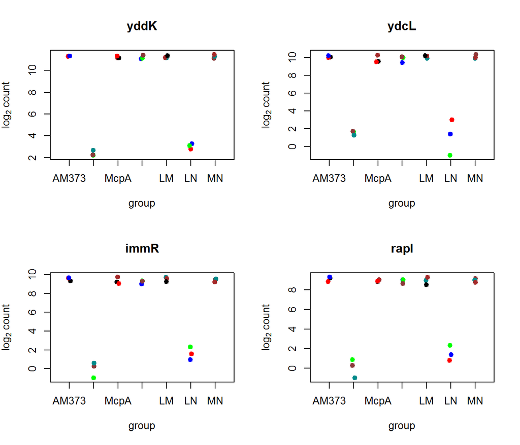

```
##      yddK ydcL immR rapI
## [1,]    1    1    1    1
## [2,]    2    2    2    2
## [3,]    3    3    3    3
## [4,]    4    4    4    4
## [5,]    5    5    5    5
## [6,]    6    6    6    6
## [7,]    7    7    7    7
```

```
##            ME_name DEGs all_in_cat    perc Up Dwn
## 1    PBSX prophage   29         42 0.69000  0  29
## 2           ICEBs1   16         27 0.59300 16   0
## 3 SP-beta prophage    7        189 0.03700  5   2
## 4         nonphage   15       3829 0.00392  8   7
## 8    no assignment    3         NA      NA NA  NA
```

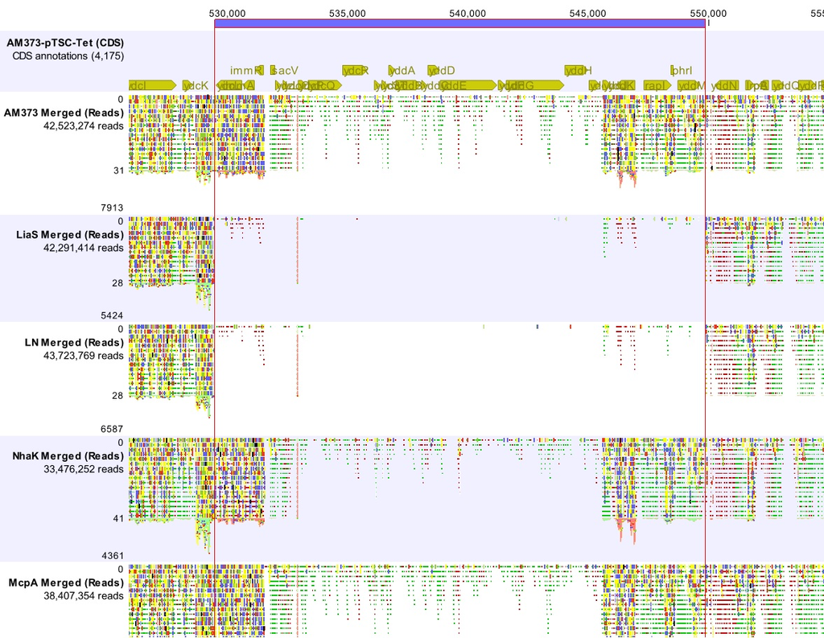